# Chapter 4 Digital Soil Mapping

## 4.1 Principles

Digital soil mapping (DSM) is a methodological framework to create soil attribute maps on the basis of the quantitative relationships between spatial soil databases and environmental covariates. The quantitative relations can be modelled by different statistical approaches, most of them considered machine learning techniques. Environmental covariates are spatially explicit proxies of soil-forming factors that are employed as predictors of the geographical distribution of soil properties. The methodology has evolved from the theories of soil genesis developed by Dokuchaev (1883) in his work the Russian Chernozems, which later were formalised by Jenny (1941) with the equation of the soil-forming factors. The conceptual equation of soil-forming factors has been updated by McBratney, Santos and Minasny (2003) as follow:

$$\begin{equation}
S = f\left(s,c,o,r,p,a,n\right)
\tag{4.1}
\end{equation}$$

Where $S$ is the soil classes or attributes (to be modelled) as a function of “$s$” as other soil properties, “$c$” as climatic properties, “$o$” as organisms, including land cover and human activity, “$r$” as terrain attributes, “$p$” as parent material, “$a$” as soil age, and “$n$” as the geographic position.

## 4.2 Environmental covariates

There is an constantly increasing range of global datasets that can be used as environmental covariates. Covariates usually provide information on the soil forming factors. However, they are always only an approximation to the reality in the field. The selection of covariates aims to give the most accurate picture of the reality and thus complement each other. In the case of climatic covariates for instance, useful covariates should not only cover the long-term mean annual temperature or precipitation over an climatic reference period (30 years) but also inform about seasonal patterns or even diurnal variability. Still, when selecting covariates one has to keep in mind that there is a trade-off between accurate representation of reality and overfitting the model used for modelling.

## 4.3 Machine learning techniques

A broad range of modelling approaches coexist in order to establish quantitative relationships between environmental covariates and the target soil properties to be mapped. The plethora of methods cannot be listed here as it was summarised in multiple review papers (Khaledian and Miller, 2020; Lamichhane, Kumar and Wilson, 2019; Ma *et al.*, 2019; Padarian, Minasny and McBratney, 2019; Wadoux, Minasny and McBratney, 2020). Traditionally, multiple linear regression models can be used to quantify the relationships which continues to be the most applied mapping method to map for instance soil organic carbon (Lamichhane, Kumar and Wilson, 2019). In addition to that, regression Kriging methods combine linear regressions and an stochastic interpolation of the regression residuals based on their spatial autocorrelation (Yigini *et al.*, 2018). However, machine learning algorithms with more flexible assumptions, i.e. non-linear relationships, have become more and more popular as the mapping performance was substantially improved and the versatility of the algorithms can be detect more complex relationships. Among the most commonly used non-linear machine learning models is random forest (Breiman, 2001). The random forest algorithm splits a dataset into subsets and uses a random selection of covariates (predictors) to identify homogeneous groups. The procedure of classifying is repeated many times and in the end the prediction is averaged. Finally, quantile regression forests (QRF) derive from random forest models (Meinshausen, 2006). The benefit of QRF is the ability to predict not only the mean of the prediction but also to provide more information on the uncertainty and probability distribution.

## 4.4 Mapping of soil nutrients and associated soil attributes

DSM has been used to produce maps of soil nutrients at regional to continental scales. For instance, Hengl *et al.* (2017) predicted 15 soil nutrients at a 250 m resolution in Africa using a random forest model (Wright, Ziegler and König, 2016). The soil nutrient observations were collected for topsoils at locations that were unevenly distributed over the continent and a set of spatially-explicit environmental covariates including soil properties. In 2021, the map resolution was increased to 30 x 30 m by using additional soil samples (Hengl *et al.*, 2021). In Europe maps of chemical soil properties, including macronutrients like potassium and phosphorus, were mapped based on a gaussian process regression using the LUCAS soil database (Ballabio *et al.*, 2019). Global efforts to map nutrients in a harmonised way are suffering of constraints due to limited availability of appropriate soil data. The country-driven approach of the GSP has therefore the potential to improve data availability through the country-driven approach as it uses largely unexplored soil data, a harmonised mapping approach combined with national expertise on the regional soil resources. Therefore, in this technical manual, we present a DSM framework to map soil nutrients and associated properties using soil observations with latitude and longitude coordinates (point-support) (Figure 4.1).

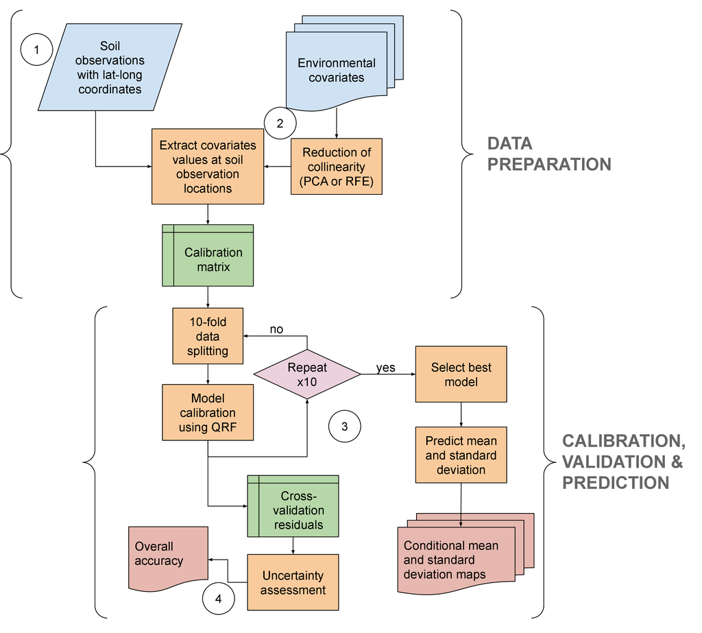

Figure 4.1: Digital soil mapping approach for point-support data. Circles are the steps.

### References

**Ballabio, C., Lugato, E., Fernández-Ugalde, O., Orgiazzi, A., Jones, A., Borrelli, P., Montanarella, L. & Panagos, P.** 2019. Mapping LUCAS topsoil chemical properties at european scale using gaussian process regression. *Geoderma*, 355: 113912.

**Breiman, L.** 2001. Random forests. *Machine Learning*, 45(1): 5–32. https://doi.org/10.1023/A:1010933404324

**Dokuchaev, V.** 1883. *The russian chernozem report to the free economic society*. Imperial University of St. Petersburg: St. Petersburg)[in Russian].

**Hengl, T., Leenaars, J.G.B., Shepherd, K.D., Walsh, M.G., Heuvelink, G.B.M., Mamo, T., Tilahun, H., Berkhout, E., Cooper, M., Fegraus, E., Wheeler, I. & Kwabena, N.A.** 2017. Soil nutrient maps of sub-saharan africa: Assessment of soil nutrient content at 250 m spatial resolution using machine learning, 109: 77–102. https://doi.org/10.1007/s10705-017-9870-x

**Hengl, T., Miller, M.A., Križan, J., Shepherd, K.D., Sila, A., Kilibarda, M., Antonijević, O., Glušica, L., Dobermann, A., Haefele, S.M. & others**. 2021. African soil properties and nutrients mapped at 30 m spatial resolution using two-scale ensemble machine learning. *Scientific Reports*, 11(1): 1–18.

**Jenny, H.** 1941. A system of quantitative pedology. In “factors of soil formation”. McGraw Hill: New York.

**Khaledian, Y. & Miller, B.A.** 2020. Selecting appropriate machine learning methods for digital soil mapping. *Applied Mathematical Modelling*, 81: 401–418.

**Lamichhane, S., Kumar, L. & Wilson, B.** 2019. Digital soil mapping algorithms and covariates for soil organic carbon mapping and their implications: A review. *Geoderma*, 352: 395–413.

**Ma, Y., Minasny, B., Malone, B.P. & Mcbratney, A.B.** 2019. Pedology and digital soil mapping (DSM). *European Journal of Soil Science*, 70(2): 216–235.

**McBratney, A.B., Santos, M.L.M. & Minasny, B.** 2003. On digital soil mapping, 117: 3–52. https://doi.org/10.1016/s0016-7061(03)00223-4

**Meinshausen, Ni.** 2006. Quantile regression forests. *Journal of Machine Learning Research*, 7(6).

**Padarian, J., Minasny, B. & McBratney, A.B.** 2019. Using deep learning for digital soil mapping. *Soil*, 5(1): 79–89.

**Wadoux, A.M.-C., Minasny, B. & McBratney, A.B.** 2020. Machine learning for digital soil mapping: Applications, challenges and suggested solutions. *Earth-Science Reviews*, 210: 103359.

**Wright, M.N., Ziegler, A. & König, I.R.** 2016. Do little interactions get lost in dark random forests? *BMC bioinformatics*, 17(1): 1–10.